# Reproducible Research_PA1

Arunava Dalal

November 24, 2017

# 1. Loading and preprocessing the data

### Unzip and load the filw

```r
act <- read.csv(unz("activity.zip","activity.csv"))
act$date <- as.Date(act$date, format = "%Y-%m-%d")
```

# 2. What is mean total number of steps taken per day?

In this section the missing values in the dataset have been ignored

### Calculate total number of steps taken per day

For this we have used the aggregate function and output stored in steps.daily.

```r
steps.daily <- aggregate(steps ~ date, rm.ma =TRUE, data = act, sum)
```

Sample of the output is given below

```r
head(steps.daily)
```

```
##         date steps
## 1 2012-10-02   127
## 2 2012-10-03 11353
## 3 2012-10-04 12117
## 4 2012-10-05 13295
## 5 2012-10-06 15421
## 6 2012-10-07 11016
```

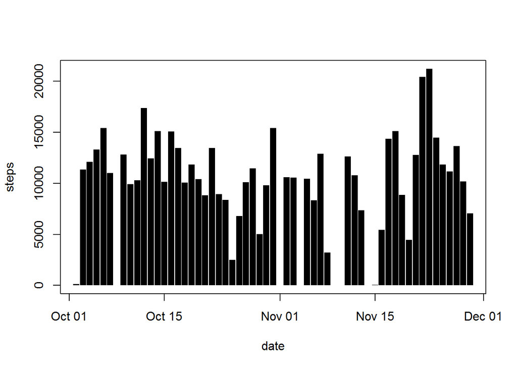

```r
plot(steps.daily, type ="h", lwd = 8, lend = "butt")
```

### Mean and Median of the total number of steps taken per day

Output stored in steps.daily.mean and steps.daily.median respectively

```r
steps.daily.mean <- aggregate(steps ~ date, rm.ma =TRUE, data = act, mean)
steps.daily.median <- aggregate(steps ~ date, rm.ma =TRUE, data = act, median)
```

Sample output shown below.

```r
head(steps.daily.mean)
```

```
##         date    steps
## 1 2012-10-02  0.43750
## 2 2012-10-03 39.41667
## 3 2012-10-04 42.06944
## 4 2012-10-05 46.15972
## 5 2012-10-06 53.54167
## 6 2012-10-07 38.24653
```

```r
head(steps.daily.median)
```

```
##         date steps
## 1 2012-10-02     0
## 2 2012-10-03     0
## 3 2012-10-04     0
## 4 2012-10-05     0
## 5 2012-10-06     0
## 6 2012-10-07     0
```

# What is the average daily activity pattern?

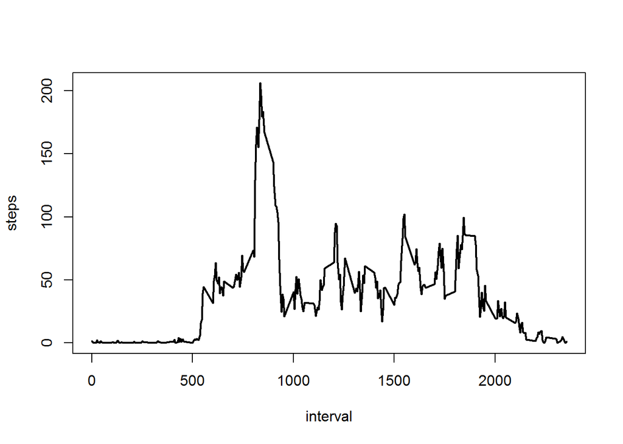

```r
steps.interval <- aggregate(steps ~ interval, data = act, mean)
plot(steps.interval, type = "l", lwd = 2)
```

```r
max(act$step, na.rm = TRUE)
```

```
## [1] 806
```

# Inputting missing values

#### Calculating the count of missing values

```r
sum(is.na(act))
```

```
## [1] 2304
```

### For filling up the missing values, I will be replacing the missing values with the mean of the variable act$step

```r
act1 <- act
act1$steps[is.na(act1$steps)] <- mean(na.omit(act$steps))
act1$date <- as.Date(act1$date, format = "%Y-%m-%d")
```

act1 is the new dataset where all missing values have been filled in.

To compare the datasets i.e with missing values and without missing values, I am plotting both the histograms.

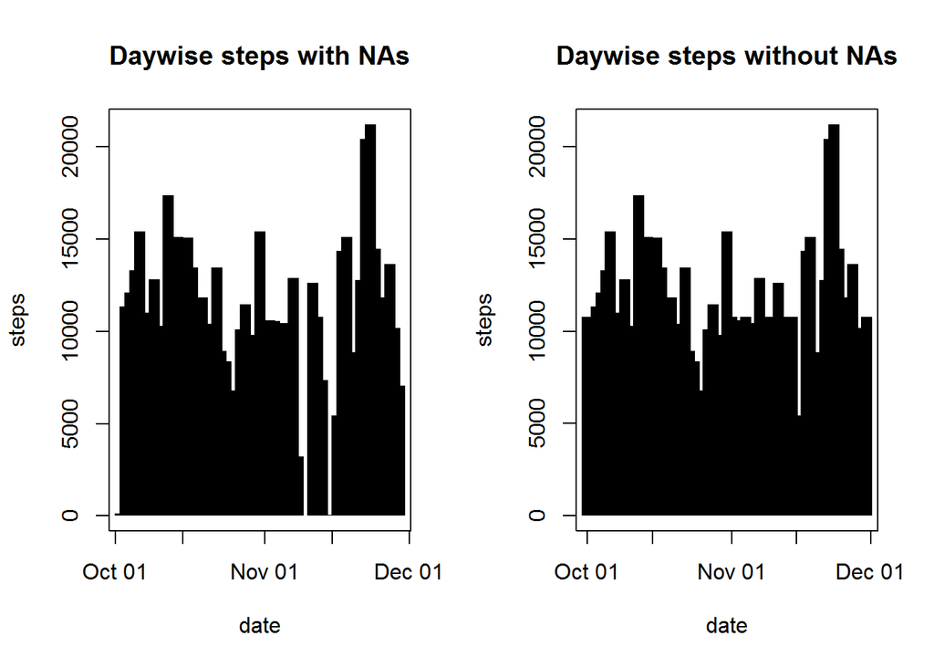

```r
steps.daily.1 <- aggregate(steps ~ date, data = act1, sum)
par(mfrow = c(1,2))
plot(steps.daily, type ="h", lwd = 8, lend = "butt", main = "Daywise steps with NAs")
plot(steps.daily.1, type ="h", lwd = 8, lend = "butt", main = "Daywise steps without NAs")
```

### Calculating the mean and median of the new dataset.

```r
steps.daily.mean.1 <- aggregate(steps ~ date, data = act1, mean)
steps.daily.median.1 <- aggregate(steps ~ date, data = act1, median)
```

Checking the sample of the new files containing mean and median.

```r
head(steps.daily.mean.1)
```

```
##         date    steps
## 1 2012-10-01 37.38260
## 2 2012-10-02  0.43750
## 3 2012-10-03 39.41667
## 4 2012-10-04 42.06944
## 5 2012-10-05 46.15972
## 6 2012-10-06 53.54167
```

```r
head(steps.daily.median.1)
```

```
##         date   steps
## 1 2012-10-01 37.3826
## 2 2012-10-02  0.0000
## 3 2012-10-03  0.0000
## 4 2012-10-04  0.0000
## 5 2012-10-05  0.0000
## 6 2012-10-06  0.0000
```

### Comment

1. The histogram with no missing values is continuous and obviously there is change in the daywise mean and median.
2. In the new dataset, as there is no missing values, so days of non activity by the individual has been lost which maybe useful in some other analysis.

# Are there differences in activity patterns between weekdays and weekends?

### Create a new factor variable in the dataset with two levels - “weekday” and “weekend” indicating whether a given date is a weekday or weekend day.

2 data sets have been created namely “weekday” and “weekend” which consits details of weekdays and weekends respectively.

```r
act1$wday <- as.factor(weekdays(act1$date))
act1$wday.num <- as.POSIXlt(act1$date)$wday
act1$weekday <- ifelse(act1$wday.num == 0 | act1$wday.num == 6, "weekend","weekday")
weekday <- act1[act1$weekday == "weekday",]
weekend <- act1[act1$weekday == "weekend",]
```

### Make a panel plot containing a time series plot (i.e. type = “l”) of the 5-minute interval (x-axis) and the average number of steps taken, averaged across all weekday days or weekend days (y-axis).

Aggregate function is used to get the average number of steps taken, averaged across weekdays and weekends.

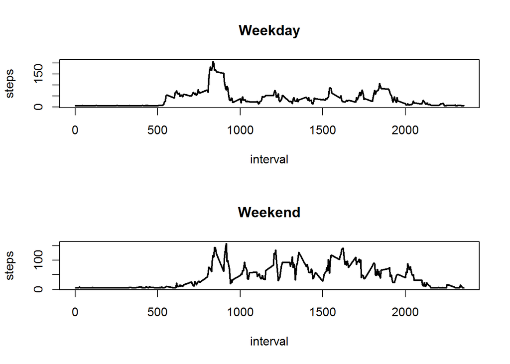

```r
weekday_mean <- aggregate(steps ~ interval, data = weekday, FUN = mean)
weekend_mean <- aggregate(steps ~ interval, data = weekend, FUN = mean)

par(mfrow = c(2,1))
plot(weekday_mean,type = "l", lwd = 2, main = "Weekday")
plot(weekend_mean,type = "l", lwd = 2, main = "Weekend")
```